```python
from part4_simstudy import *
from matplotlib import pyplot as pp
```

# Verification

## 4.2.1: Auto Correlation

First, we need to understand what correlation acutally means: It measures the linear dependency between random variables, or in case of the autocorrelation between itself and a later point in time. The correlation is bounded in the interval [-1,1] where the edges mean negative or positive linear relationship respectively. Now to my experiment.

The longer the sequences are, the more accurate the values of the correlation get to the actual value.

The acutal value of the correlation is not reached within a finite number of samples. For seq1=[1,-1,1,-1,...] the autocorrelation should switch between -1 and 1 since the sequence is either perfectly linear or perfectly antilinear. Still, the value deviation comes from the fact that I decided after some testing with the unittest to implement the Cov[X,Y] = E[XY]-E[X]*E[Y]. I implemented an additonal function that calculates the covariance with the 1/(n-1) factor and as you can see it is closer to the acutal value, also with a low k! The reason why I didnt use it in my implementation is that it failled the unittest.

For the second sequence the same observations as for the first sequence remain true only the values change.

```python
task_4_2_1(k=10)
task_4_2_1(k=10, do_compare=True)
task_4_2_1(k=1000)
task_4_2_1(k=1000, do_compare=True)
```

```
k=10 -------------------------------------------------------------------
Name: Cross Corr.; covariance = 0.0; correlation = 0.0
Name: Auto Corr. for s1
Lag = 0; covariance = 1.0; correlation = 0.9833333333333334
Lag = 1; covariance = -1.0; correlation = -0.9833333333333334
Name: Auto Corr. for s2
Lag = 0; covariance = 0.8888888888888888; correlation = 0.9833333333333333
Lag = 1; covariance = -0.4444444444444444; correlation = -0.49166666666666664
Lag = 2; covariance = -0.4444444444444444; correlation = -0.49166666666666664
k=10 -------------------------------------------------------------------
Name: Cross Corr.; covariance = 0.0; correlation = 0.0
Name: Auto Corr. for s1
Lag = 0; covariance = 1.0; correlation = 0.9833333333333334
Lag = 1; covariance = -1.0; correlation = -0.9833333333333334
Name: Auto Corr. for s2
Lag = 0; covariance = 0.8888888888888888; correlation = 0.9833333333333333
Lag = 1; covariance = -0.4444444444444444; correlation = -0.49166666666666664
Lag = 2; covariance = -0.4444444444444444; correlation = -0.49166666666666664
 ---- Cov. & Corr. for Seq.1 with different formular for k=10 ----
Cov: 1.0169491525423728, Corr. 1.0
Cov: -1.0169491525423728, Corr. -1.0
 ---- Cov. & Corr. for Seq.2 with different formular for k=10 ----
Cov: 0.9039548022598869, Corr. 0.9999999999999999
Cov: -0.45197740112994367, Corr. -0.5000000000000002
Cov: -0.45197740112994367, Corr. -0.5000000000000002
k=1000 -------------------------------------------------------------------
Name: Cross Corr.; covariance = 0.0; correlation = 0.0
Name: Auto Corr. for s1
Lag = 0; covariance = 1.0; correlation = 0.9998333333333334
Lag = 1; covariance = -1.0; correlation = -0.9998333333333334
Name: Auto Corr. for s2
Lag = 0; covariance = 0.8888888888888888; correlation = 0.9998333333333331
Lag = 1; covariance = -0.4444444444444444; correlation = -0.49991666666666656
Lag = 2; covariance = -0.4444444444444444; correlation = -0.49991666666666656
k=1000 -------------------------------------------------------------------
Name: Cross Corr.; covariance = 0.0; correlation = 0.0
Name: Auto Corr. for s1
Lag = 0; covariance = 1.0; correlation = 0.9998333333333334
Lag = 1; covariance = -1.0; correlation = -0.9998333333333334
Name: Auto Corr. for s2
Lag = 0; covariance = 0.8888888888888888; correlation = 0.9998333333333331
Lag = 1; covariance = -0.4444444444444444; correlation = -0.49991666666666656
Lag = 2; covariance = -0.4444444444444444; correlation = -0.49991666666666656
 ---- Cov. & Corr. for Seq.1 with different formular for k=1000 ----
Cov: 1.0001666944490748, Corr. 1.0
Cov: -1.0001666944490748, Corr. -1.0
 ---- Cov. & Corr. for Seq.2 with different formular for k=1000 ----
Cov: 0.8890370617325141, Corr. 1.0000000000000033
Cov: -0.44451853086625326, Corr. -0.49999999999999745
Cov: -0.44451853086625326, Corr. -0.49999999999999745
```

# Simulation Study **Vol. 4**

# Analysis and General Questions

## 4.4.1 Lag Size

**correlation coefficient**: measures the linear dependency between RVs. The covariance basically shows the same thing but without normalization, so it is more difficult to find a meaningful interpretation since the amplitude is harder to classify.

**Lag Size**: The autocorelation and lag size are negativly corrlated, meaning the larger the lag size, the smaller the autocorrelation. If rho is set to a highe value, the autocorelation decreses slower with a growing lag size. For the **test sequences**, seq1 a lag soize of 0,1 and for seq2 a lag size of 0,1,2 should be chosen. AS I said before the maximum lag should be lower than the period since the correlation coeffs then starts to repeat, thus no new information is revealed.

## 4.4.2 Cororelation Times in the DES

Yeez, that was a lot of work.

**Correlation between IAT and waiting time of a packet**: Are negative correlated. This makes sense since when the IAT gets big, less packets arrive, thus there are less packets in the buffer which leads to a smaller waiting time per packet. The correlation gets smaller for a bigger rho.

**Correlation between IAT and service time of a packet**: Basically zero, indicating no correlation accross all rho. This makes sense since the two exponential distributions where chosen to be independent

**Correlation between IAT and system time (waiting time + service time) of a packet**: Negatively correlated. It changes significantly with rho. For rho=0.01 it is basically 0. For rho=0.5 the correlation coeff. is -0.229. For rho=0.8 its -0.17 and for rho=0.95 its -0.08. this makes sense since the system time is a combination of the waiting and service time. For a small rho the service time plays the more significant role, thus the correlation is close to 0. When rho rises, the waiting time is more significant and we already established that there is a negative correlation between IAT and waiting time. The latter decreases with an further incearsing rho, as does the correlation between IAS and system time.

**Correlation between service time and system time of a packet**: Is positive, meaning when one increases so does the other. It overall decraeses with an increasing rho since the system time is the combination of waiting and service time, the former is heavily affected by a large rho but the serivice time is not, thus the correlation decreases with a large rho.

**Auto-correlation of waiting time with lags ranging from 1 to 20 n**: Is positive and decreases with a steadily increasing lag. For larger rho the negative slopes of the curves are lower. This makes sense because in this situation the server is just quick enough to handle the arriving packets. Thus if a packet has to wait it is higly likely that another packet has to wait to, since the server is barly quick enough to handle the packets the influence can be seen for a longer time, thus the correaltion remainson higher positive values for longer.

```
rho=0.01 ------------------------------------------
Name: inter-arrival time vs. waiting time; covariance = -84.43480646660318; correlation = -0.06950339529821317
Name: inter-arrival time vs. service time; covariance = -49.559907764270974; correlation = -0.005028128304156447
Name: inter-arrival time vs. system time; covariance = -133.99471423087562; correlation = -0.013498362550612283
Name: service time vs. system time; covariance = 100.54906741428844; correlation = 0.9923848922305932
Name: waiting time with lags 1 to 20
Lag = 0; covariance = 1.5281114543472287; correlation = 0.9999006754072309
Lag = 1; covariance = -0.007347425271364888; correlation = -0.0048076961077948566
Lag = 2; covariance = -0.00704945149305738; correlation = -0.004612720681535391
Lag = 3; covariance = -0.0043676874882897995; correlation = -0.0028579418452002016
Lag = 4; covariance = -0.007347425271364888; correlation = -0.0048076961077948566
Lag = 5; covariance = -0.007347425271364888; correlation = -0.0048076961077948566
Lag = 6; covariance = -0.007347425271364888; correlation = -0.0048076961077948566
Lag = 7; covariance = -0.0047649858593664775; correlation = -0.003117909080212822
Lag = 8; covariance = -0.004665661266597308; correlation = -0.0030529172714596673
Lag = 9; covariance = -0.007347425271364888; correlation = -0.0048076961077948566
Lag = 10; covariance = -0.007347425271364888; correlation = -0.0048076961077948566
Lag = 11; covariance = -0.007347425271364888; correlation = -0.0048076961077948566
Lag = 12; covariance = -0.007347425271364888; correlation = -0.0048076961077948566
Lag = 13; covariance = -0.007347425271364888; correlation = -0.0048076961077948566
Lag = 14; covariance = -0.004963635044904817; correlation = -0.0032478926977191325
Lag = 15; covariance = 0.045393933489064196; correlation = 0.029702954340130542
Lag = 16; covariance = -0.007347425271364888; correlation = -0.0048076961077948566
Lag = 17; covariance = -0.007347425271364888; correlation = -0.0048076961077948566
Lag = 18; covariance = -0.007347425271364888; correlation = -0.0048076961077948566
Lag = 19; covariance = -0.007347425271364888; correlation = -0.0048076961077948566
Lag = 20; covariance = -0.0037717399316747812; correlation = -0.0024679909926812703
rho=0.5 ------------------------------------------
Name: inter-arrival time vs. waiting time; covariance = -256608.8828977293; correlation = -0.2600638979024177
Name: inter-arrival time vs. service time; covariance = -1302.6066218130873; correlation = -0.002525854008242925
Name: inter-arrival time vs. system time; covariance = -257911.48951954232; correlation = -0.22952340094208673
Name: service time vs. system time; covariance = 266899.21321075846; correlation = 0.4788293318795166
Name: waiting time with lags 1 to 20
Lag = 0; covariance = 936391.0719368856; correlation = 0.9998992341797663
Lag = 1; covariance = 763057.9396313636; correlation = 0.8148102564604729
Lag = 2; covariance = 636857.5326382157; correlation = 0.6800506521803835
Lag = 3; covariance = 538449.1663544591; correlation = 0.5749680077244971
Lag = 4; covariance = 456645.8070235442; correlation = 0.48761655938238047
Lag = 5; covariance = 389622.4439642939; correlation = 0.41604752011711305
Lag = 6; covariance = 334143.22973616014; correlation = 0.35680557998961765
```

[output cut: 53 more lines]

```
Lag = 6; covariance = 70081948.11067894; correlation = 0.9349165533414585
Lag = 7; covariance = 69373193.59316805; correlation = 0.9254615317768468
Lag = 8; covariance = 68662271.01471534; correlation = 0.9159775875564328
Lag = 9; covariance = 67998161.05676123; correlation = 0.907118139300947
Lag = 10; covariance = 67336297.7037735; correlation = 0.898288661504738
Lag = 11; covariance = 66660479.02846682; correlation = 0.8892730150560453
Lag = 12; covariance = 65999655.33248344; correlation = 0.8804574066308992
Lag = 13; covariance = 65367642.82565716; correlation = 0.8720261490748513
Lag = 14; covariance = 64751479.95644465; correlation = 0.8638063309688908
Lag = 15; covariance = 64172565.45931369; correlation = 0.8560834185652242
Lag = 16; covariance = 63615631.463073075; correlation = 0.8486537333718039
Lag = 17; covariance = 63041737.63996267; correlation = 0.8409977984334803
Lag = 18; covariance = 62476824.79172364; correlation = 0.8334616726942264
Lag = 19; covariance = 61920184.11612016; correlation = 0.8260359004958996
Lag = 20; covariance = 61345026.04696703; correlation = 0.8183631000938623
```

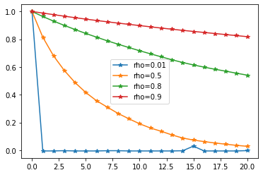

```python
#@title Standardtext für Titel
task_4_3_1()
```

## 4.4.3 Visualization of the Covariance/Correlation

The relation to the correlation values is as follows: The correlation is closer to 1 the more points are located on a straight line, or close to being located on it. A good example is the plots in the bottom left.

Comparing the service time (St) vs system time (SysP) of a packet it becomes clear that the bigger the rho, the less positively corelated the St and SysP are.

Comparing the IAT vs service time it becomes that there is no real correlation so to speak of, all measurments look the same even for a changing rho.

Both plots confirm the observations in task 4.4.2.

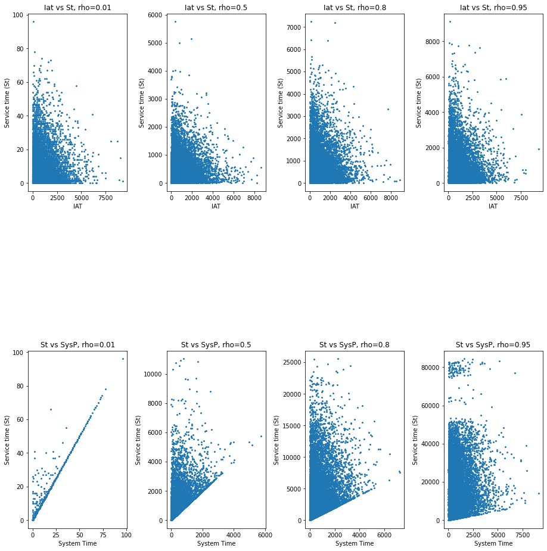

```python
task_4_3_2()
```

## 4.4.4 Auto correlation

From the two plots below it becomes very clear that statistics over 100 packets are not meaninful, thus a longer simulation time (or enough processed packets) is essential. Because of the very limited scope of the simulation the result are prone to be influenced by randomness (IAT and ST are RVs).

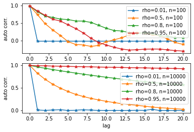

```python
task_4_3_3()
```